# Lab 13

Author

Julia Plotniak

## *Exploratory Data Analysis*

### **Summaries & distributions**

```r
library(tidyverse)
library(skimr)
library(sf)
library(ggplot2)
library(treemapify)
```

```r
# Replace with your actual file path
mags <- read_csv("NEON_soilMAGs_soilChem.csv")

# Quick look
glimpse(mags)
```

```
Rows: 5,573
Columns: 43
$ ...1                  <dbl> 1, 2, 3, 4, 5, 6, 7, 8, 9, 10, 11, 12, 13, 14, 1…
$ genomicsSampleID      <chr> "BONA_001-O-20230710", "BONA_001-O-20230710", "B…
$ soilMoisture          <dbl> 1.546, 1.546, 1.546, 1.546, 1.546, 1.546, 1.546,…
$ decimalLatitude       <dbl> 65.17445, 65.17445, 65.17445, 65.17445, 65.17445…
$ decimalLongitude      <dbl> -147.4782, -147.4782, -147.4782, -147.4782, -147…
$ elevation             <dbl> 374.1, 374.1, 374.1, 374.1, 374.1, 374.1, 374.1,…
$ soilTemp              <dbl> 8.1, 8.1, 8.1, 8.1, 8.1, 8.1, 8.1, 8.1, 8.1, 8.1…
$ soilInWaterpH         <dbl> 3.993976, 3.993976, 3.993976, 3.993976, 3.993976…
$ soilInCaClpH          <dbl> 3.449951, 3.449951, 3.449951, 3.449951, 3.449951…
$ bin_oid               <chr> "3300079481_s0", "3300079481_s1", "3300079481_s1…
$ bin_id                <chr> "3300079481_s0", "3300079481_s1", "3300079481_s1…
$ site                  <chr> "Caribou-Poker Creeks Research Watershed NEON Fi…
$ site_ID               <chr> "BONA", "BONA", "BONA", "BONA", "BONA", "BONA", …
```

[output cut: 30 more lines]

#### *Soil Chemistry Summaries*

```r
# Summarize ranges of soil chemistry variables
soil_summary <- mags %>%
  select(site_ID, subplot, soilMoisture, soilTemp, soilInWaterpH, soilInCaClpH, elevation) %>%
  skim()

soil_summary
```

Data summary

| Name | Piped data |
| --- | --- |
| Number of rows | 5573 |
| Number of columns | 7 |
| _______________________ |  |
| Column type frequency: |  |
| character | 2 |
| numeric | 5 |
| ________________________ |  |
| Group variables | None |

**Variable type: character**

| skim_variable | n_missing | complete_rate | min | max | empty | n_unique | whitespace |
| --- | --- | --- | --- | --- | --- | --- | --- |
| site_ID | 39 | 0.99 | 4 | 4 | 0 | 27 | 0 |
| subplot | 39 | 0.99 | 3 | 3 | 0 | 53 | 0 |

**Variable type: numeric**

| skim_variable | n_missing | complete_rate | mean | sd | p0 | p25 | p50 | p75 | p100 | hist |
| --- | --- | --- | --- | --- | --- | --- | --- | --- | --- | --- |
| soilMoisture | 0 | 1 | 1.24 | 2.04 | 0.04 | 0.17 | 0.32 | 1.55 | 13.19 | ▇▁▁▁▁ |
| soilTemp | 1 | 1 | 17.00 | 6.84 | 3.10 | 10.80 | 16.90 | 22.30 | 32.67 | ▅▅▇▆▂ |
| soilInWaterpH | 0 | 1 | 5.34 | 1.29 | 3.35 | 4.32 | 5.08 | 6.38 | 8.52 | ▆▇▃▃▂ |
| soilInCaClpH | 0 | 1 | 4.70 | 1.34 | 2.67 | 3.67 | 4.34 | 5.64 | 7.95 | ▆▇▃▂▃ |
| elevation | 1 | 1 | 807.07 | 841.72 | 9.80 | 297.90 | 509.10 | 1099.50 | 3540.90 | ▇▁▂▁▁ |

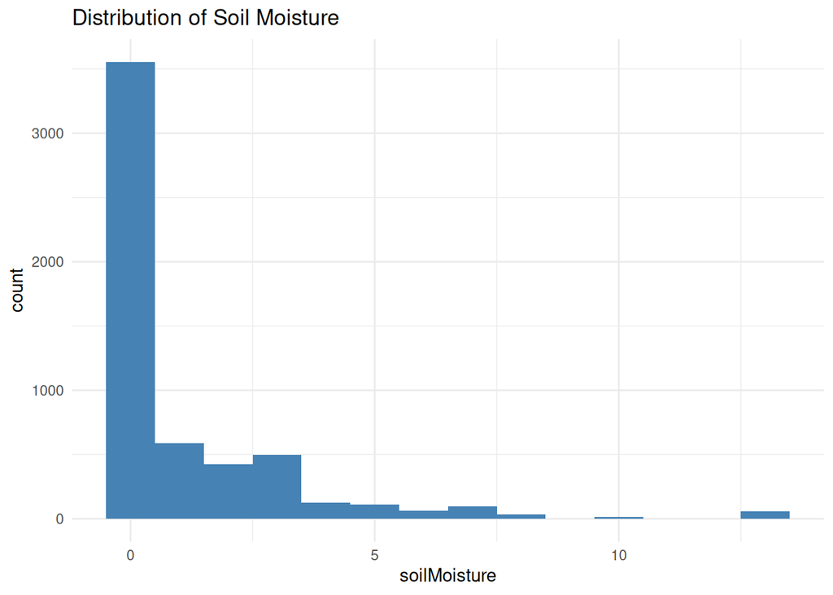

```r
# Visualize distributions: example with soil moisture
mags %>%
  ggplot(aes(x = soilMoisture)) +
  geom_histogram(binwidth = 1, fill = "steelblue") +
  theme_minimal() +
  labs(title = "Distribution of Soil Moisture")
```

#### *Taxonomic Composition*

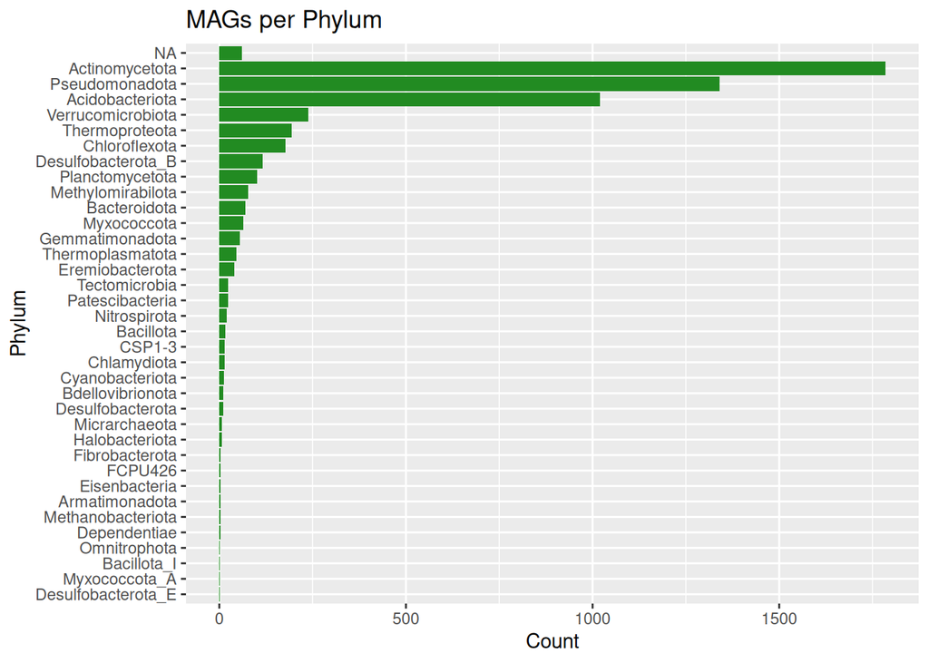

```r
# Count MAGs per phylum
tax_counts <- mags %>%
  count(phylum, sort = TRUE)

tax_counts %>%
  ggplot(aes(x = reorder(phylum, n), y = n)) +
  geom_col(fill = "forestgreen") +
  coord_flip() +
  labs(title = "MAGs per Phylum", x = "Phylum", y = "Count")
```

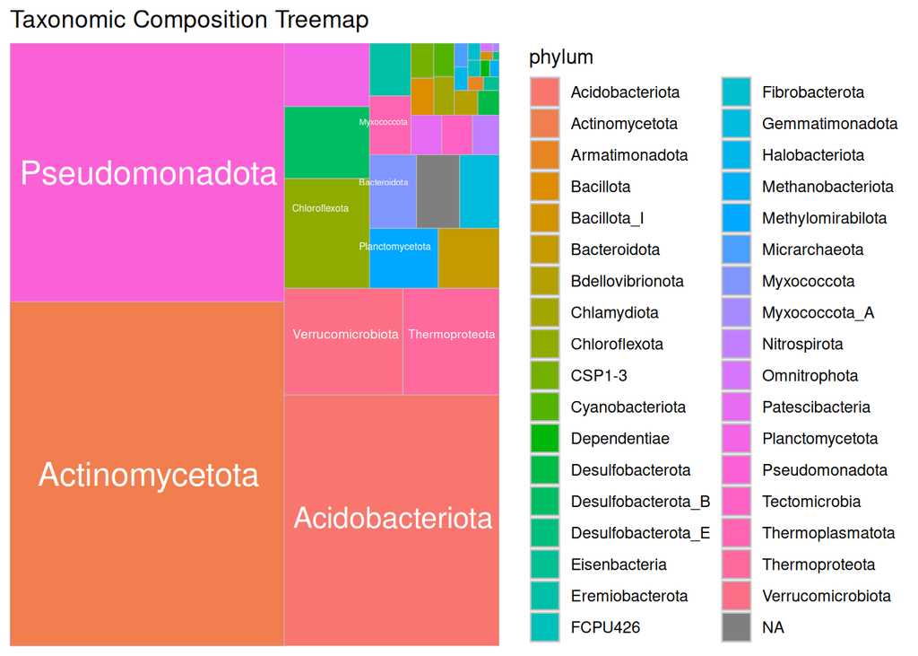

```r
# Treemap visualization
tax_counts %>%
  ggplot(aes(area = n, fill = phylum, label = phylum)) +
  geom_treemap() +
  geom_treemap_text(colour = "white", place = "centre") +
  labs(title = "Taxonomic Composition Treemap")
```

#### *Geographic Spread*

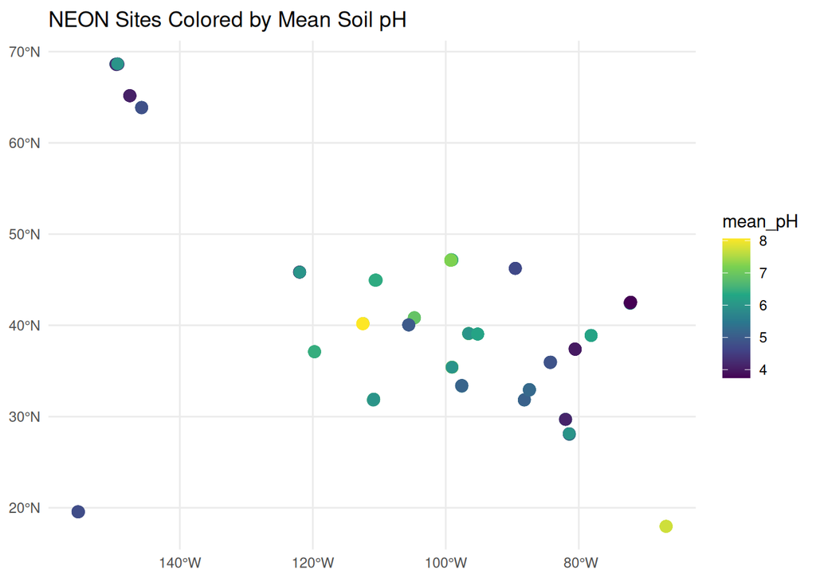

```r
# Remove rows with missing coordinates
sites_sf <- mags %>%
  distinct(site_ID, decimalLatitude, decimalLongitude) %>%
  filter(!is.na(decimalLatitude), !is.na(decimalLongitude)) %>%
  st_as_sf(coords = c("decimalLongitude","decimalLatitude"), crs = 4326)

# Summarize diversity per site
site_summary <- mags %>%
  group_by(site_ID) %>%
  summarize(mean_pH = mean(soilInWaterpH, na.rm = TRUE),
            richness = n_distinct(bin_id))

# Join summaries to spatial data
sites_sf <- sites_sf %>%
  left_join(site_summary, by = "site_ID")

# Map sites colored by mean soil pH
ggplot(sites_sf) +
  geom_sf(aes(color = mean_pH), size = 3) +
  scale_color_viridis_c() +
  theme_minimal() +
  labs(title = "NEON Sites Colored by Mean Soil pH")
```

## *Community Ecology Approaches*

### **Alpha diversity**

#### *Alpha diversity is the mean species diversity at a local scale accounting for the number of species present (richness) and their abundance (evenness) in the area. In the CoPilot-generated analysis, Shannon diversty and Pielou’s evenness are used.*

#### *Shannon index is a method of calculating diversity using species evenness and richness where higher values equal greater diversity.*

#### *Pielou’s evenness exclusively focuses on evenness and the distribution of species in an area.*

```r
library(vegan)
# Richness: number of unique MAGs per site
alpha_div <- mags %>%
  group_by(site_ID) %>%
  summarize(richness = n_distinct(bin_id))

# Evenness: using Shannon index
# First build site x MAG abundance matrix
comm_matrix <- mags %>%
  count(site_ID, bin_id) %>%
  pivot_wider(names_from = bin_id, values_from = n, values_fill = 0)

# Extract abundance data
abund <- comm_matrix %>% select(-site_ID)

# Shannon diversity and Pielou's evenness
shannon <- diversity(abund, index = "shannon")
richness <- specnumber(abund)
evenness <- shannon / log(richness)

alpha_results <- tibble(
  site_ID = comm_matrix$site_ID,
  richness = richness,
  shannon = shannon,
  evenness = evenness
)

alpha_results
```

```
# A tibble: 28 × 4
   site_ID richness shannon evenness
   <chr>      <int>   <dbl>    <dbl>
 1 BONA         256    5.55        1
 2 CLBJ         276    5.62        1
 3 CPER         122    4.80        1
 4 DCFS         258    5.55        1
 5 DEJU         474    6.16        1
 6 DSNY         116    4.75        1
 7 GUAN         154    5.04        1
 8 HARV         253    5.53        1
 9 KONZ         208    5.34        1
10 LENO         167    5.12        1
# ℹ 18 more rows
```

### **Beta diversity**

#### *Beta diversity is the variation in species diversity between two separate areas. The CoPilot analysis uses NMDS, CAP, and PERMANOVA to examine this.*

#### *NMDS (Non-metric Multidimensional Scaling) is an unconstrained ordination method used to arrange sites based on their dissimilarities.*

#### *CAP (Canonical Analysis of Principal Coordinates) is a constrained ordination method that tests how much community variation is explained by environmental gradients.*

#### *PERMANOVA (Permutational Multivariate Analysis of Variance) is a test used to show differences in community composition among groups.*

##### Step 1: Prepare the community matrix

```r
library(tidyverse)

# Drop rows with missing site_ID or bin_id
comm_matrix <- mags %>%
  filter(!is.na(site_ID), !is.na(bin_id)) %>%
  count(site_ID, bin_id) %>%
  pivot_wider(names_from = bin_id, values_from = n, values_fill = 0)

# Extract abundance data
abund <- comm_matrix %>% select(-site_ID)

# Assign row names safely
rownames(abund) <- comm_matrix$site_ID
```

##### Step 2: Prepare environmental data

```r
env_data <- mags %>%
  group_by(site_ID) %>%
  summarize(
    soilMoisture = mean(soilMoisture, na.rm = TRUE),
    soilTemp = mean(soilTemp, na.rm = TRUE),
    soilInWaterpH = mean(soilInWaterpH, na.rm = TRUE),
    soilInCaClpH = mean(soilInCaClpH, na.rm = TRUE),
    elevation = mean(elevation, na.rm = TRUE)
  )

env_data <- env_data %>% filter(site_ID %in% rownames(abund))
env_data <- env_data[match(rownames(abund), env_data$site_ID), ]
```

##### Step 3: NMDS (unconstrained coordination)

```r
set.seed(123)
nmds <- metaMDS(abund, distance = "bray", k = 2, trymax = 100)
```

```
*** Best solution was not repeated -- monoMDS stopping criteria:
   100: stress < smin
```

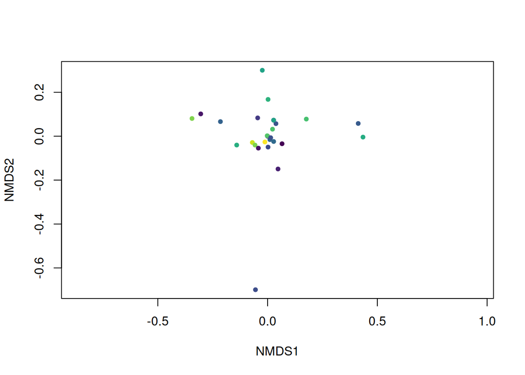

```r
# Plot NMDS with sites colored by soil pH
ordiplot(nmds, type = "n")
points(nmds, display = "sites",
       col = scales::col_numeric("viridis", NULL)(env_data$soilInWaterpH),
       pch = 19)
```

##### Step 4: CAP (constrained coordination)

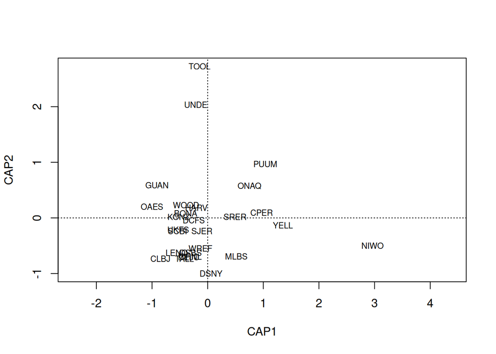

```r
cap <- capscale(abund ~ soilMoisture + soilTemp + soilInWaterpH + soilInCaClpH + elevation,
                data = env_data, distance = "bray")

plot(cap, display = "sites")
```

##### Step 5: PERMANOVA

```r
adonis_results <- adonis2(abund ~ soilMoisture + soilTemp + soilInWaterpH + soilInCaClpH + elevation,
                          data = env_data, method = "bray")
adonis_results
```

```
Permutation test for adonis under reduced model
Permutation: free
Number of permutations: 999

adonis2(formula = abund ~ soilMoisture + soilTemp + soilInWaterpH + soilInCaClpH + elevation, data = env_data, method = "bray")
         Df SumOfSqs      R2  F Pr(>F)
Model     5      2.5 0.19231  1      1
Residual 21     10.5 0.80769
Total    26     13.0 1.00000
```

### **PERMANOVA**

#### *PERMANOVA assesses significance using permutations (ordered arrangements) of variation components that are explained by residuals or predictors.*

##### Step 1: Prepare the community matrix

```r
library(tidyverse)
library(vegan)

# Build site x MAG abundance matrix
comm_matrix <- mags %>%
  filter(!is.na(site_ID), !is.na(bin_id)) %>%
  count(site_ID, bin_id) %>%
  pivot_wider(names_from = bin_id, values_from = n, values_fill = 0)

# Extract abundance data
abund <- comm_matrix %>% select(-site_ID)
rownames(abund) <- comm_matrix$site_ID
```

##### Step 2: Prepare environmental data

```r
env_data <- mags %>%
  group_by(site_ID) %>%
  summarize(
    soilMoisture = mean(soilMoisture, na.rm = TRUE),
    soilTemp = mean(soilTemp, na.rm = TRUE),
    soilInWaterpH = mean(soilInWaterpH, na.rm = TRUE),
    soilInCaClpH = mean(soilInCaClpH, na.rm = TRUE),
    elevation = mean(elevation, na.rm = TRUE),
    latitude = mean(decimalLatitude, na.rm = TRUE),
    longitude = mean(decimalLongitude, na.rm = TRUE)
  )

# Align order with abundance matrix
env_data <- env_data %>%
  filter(site_ID %in% rownames(abund)) %>%
  arrange(match(site_ID, rownames(abund)))
```

##### Step 3: Run PERMANOVA

```r
# Test soil chemistry + geography effects
adonis_results <- adonis2(
  abund ~ soilMoisture + soilTemp + soilInWaterpH + soilInCaClpH + elevation + latitude + longitude,
  data = env_data,
  method = "bray",
  permutations = 999
)

adonis_results
```

```
Permutation test for adonis under reduced model
Permutation: free
Number of permutations: 999

adonis2(formula = abund ~ soilMoisture + soilTemp + soilInWaterpH + soilInCaClpH + elevation + latitude + longitude, data = env_data, permutations = 999, method = "bray")
         Df SumOfSqs      R2  F Pr(>F)
Model     7      3.5 0.26923  1      1
Residual 19      9.5 0.73077
Total    26     13.0 1.00000
```

##### Step 4: Interpret results

###### *Pr(>F) = 1 shows that the model is not statistically significant, meaning the predictors do not explain community variation in the MAG data better than random chance. The R-squared model is 0.269, meaning about 26.9% of the variation in MAG community composition is explained by environmental variables, but the others are unexplained.*